# Progetto gruppo 2: BREAST CANCER

Da consegnare:

1. Codice R
2. Report dei risultati:

• Breve introduzione discorsiva allo studio (contesto clinico e obiettivo dell’analisi)

• Statistiche descrittive su tutte le variabili del campione in studio

• Analisi univariate dell’associazione di ciascun fattore con l’outcome in studio

• Analisi principale dello studio:

```
• sviluppo del modello di rischio con covariate cliniche al basale (valutare forma funzionale delle variabili continue e assunzione «Proportional Hazards»)

• valutazione della performance del modello (calibrazione, discriminazione, Net Benefit) per la predizione del rischio di evento ad un time-point fisso (es. progetto 1: 5 anni; progetto 2: 12 mesi).

• sviluppo del modello di rischio che contiene anche il marker misurato longitudinalmente (progetto 1) o il set selezionato di variabili di espressione genica (progetto 2)

• Predizione del rischio di evento per 3 soggetti «tipo» (scelti casualmente nel dataset o nuovi ipotetici soggetti) basata sul nuovo modello

• Breve commento discorsivo ai risultati. Menzionare eventuali limiti dei dati e problematiche riscontrate durante analisi.
```

# **1. Breve introduzione discorsiva allo studio (contesto clinico e obiettivo dell’analisi)**

Scopo del progetto: Valutazione della performance predittiva di un modello di rischio con covariate cliniche e sviluppo di un modello analogo che include tra i predittori anche un set di variabili di espressione genica selezionate tramite regressione penalizzata.

DATASET: breast cancer

Nr. osservazioni: 144

Variabili:

- time: tempo di follow-up libero da metastasi (in mesi).
- event: indicatore di evento (1 = metastasi o morte; 0 = censura).
- Diam: Diametro del tumore (2 livelli).
- N: numero di linfonodi coinvolti (2 livelli).
- ER: status del recettore di estrogeni (2 livelli).
- Grade: grado del tumore (tre livelli ordinati).
- Age: età della paziente alla diagnosi (in anni).
- TSPYL5 … C20orf46: misura di espressione genica di 70 geni potenzialmente prognostici

# **2. Statistiche descrittive**

### **Operazioni preliminari**

```r
#carico le librerie necessarie
library(survival)
library(survminer)
library(pander)
```

```r
#carico il dataset
setwd(dirname(rstudioapi::getActiveDocumentContext()$path))
dataset = read.table("dataset.csv",  na.strings=".", sep = "\t",  header=T, row.names=NULL)
```

```r
# Rimuovo l'id della riga
dataset = dataset[, -1]
# Prendo solo le covariate cliniche
dataset = dataset[1:7]
# Converto le variabili categoriche in categorie numeriche
dataset$Diam = ifelse(dataset$Diam == "<=2cm", 0, 1)
dataset$N = ifelse(dataset$N == "<4", 0, 1)
dataset$ER = ifelse(dataset$ER == "Negative", 0, 1)
dataset$Grade = ifelse(dataset$Grade == "Poorly diff", 0,
                       ifelse(dataset$Grade == "Intermediate", 1, 2))
```

### **Computazione statistiche**

```r
pander(summary(dataset), big.mark=",") #-- statistiche
```

```
---------------------------------------------------------------------
       time             event             Diam              N
------------------ ---------------- ---------------- ----------------
 Min.  : 0.05476    Min.  :0.0000    Min.  :0.0000    Min.  :0.0000

 1st Qu.: 4.70568   1st Qu.:0.0000   1st Qu.:0.0000   1st Qu.:0.0000

 Median : 6.99521   Median :0.0000   Median :0.0000   Median :0.0000

  Mean : 7.35130     Mean :0.3333     Mean :0.4931     Mean :0.2639

 3rd Qu.: 9.98631   3rd Qu.:1.0000   3rd Qu.:1.0000   3rd Qu.:1.0000

 Max.  :17.65914    Max.  :1.0000    Max.  :1.0000    Max.  :1.0000
---------------------------------------------------------------------

Table: Table continues below


-------------------------------------------------
       ER             Grade             Age
---------------- ---------------- ---------------
 Min.  :0.0000    Min.  :0.0000    Min.  :26.00

 1st Qu.:1.0000   1st Qu.:0.0000   1st Qu.:41.00

 Median :1.0000   Median :1.0000   Median :45.00

  Mean :0.8125     Mean :0.9514     Mean :44.31

 3rd Qu.:1.0000   3rd Qu.:2.0000   3rd Qu.:49.00

 Max.  :1.0000    Max.  :2.0000    Max.  :53.00
-------------------------------------------------
```

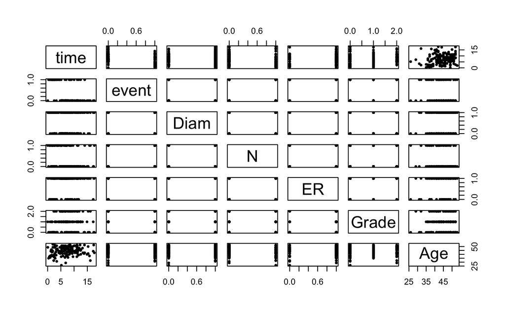

```r
plot(dataset, pch=19, cex=.5) #-- scatter plot multivariato
```

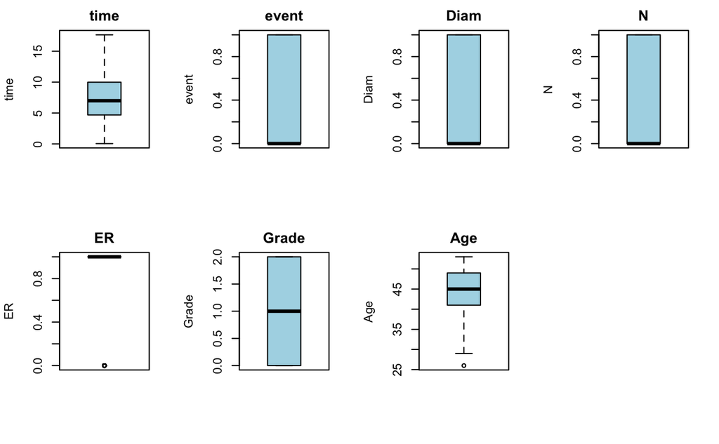

```r
par(mfrow=c(2, 4))
for (i in names(dataset)){
  boxplot(dataset[, i], main=i, col="lightblue", ylab=i)
}
```

### **3. Analisi univariate dell’associazione di ciascun fattore con l’outcome in studio**

```r
pander(cor(dataset),big.mark=",") #-- matrice di correlazione
```

```
----------------------------------------------------------------------------
  &nbsp;       time      event      Diam        N          ER       Grade
----------- ---------- --------- ---------- ---------- ---------- ----------
 **time**       1       -0.5067   0.005783   -0.1633     0.1474     0.1187

 **event**   -0.5067       1       0.2161     0.312      -0.151    -0.2378

 **Diam**    0.005783   0.2161       1        0.355     -0.1312    -0.3284

   **N**     -0.1633     0.312     0.355        1       -0.07569   -0.2039

  **ER**      0.1474    -0.151    -0.1312    -0.07569      1        0.3784

 **Grade**    0.1187    -0.2378   -0.3284    -0.2039     0.3784       1

  **Age**     0.1449    -0.179    0.08956    -0.2239    0.09781    0.000231
----------------------------------------------------------------------------

Table: Table continues below


----------------------
  &nbsp;       Age
----------- ----------
 **time**     0.1449

 **event**    -0.179

 **Diam**    0.08956

   **N**     -0.2239

  **ER**     0.09781

 **Grade**   0.000231

  **Age**       1
----------------------
```

### **4. Sviluppo del modello di rischio con covariate cliniche al basale**

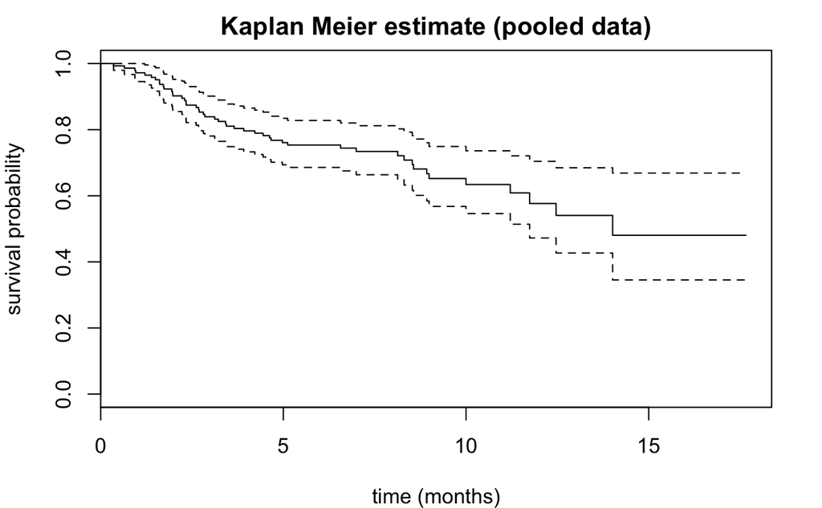

```r
# Kaplan-Meier
fit = survfit(Surv(dataset$time, dataset$event) ~ 1)
par(mar=c(4, 4, 2, 2))
plot(fit, xlab='time (months)', ylab='survival probability')
title('Kaplan Meier estimate (pooled data)')
```

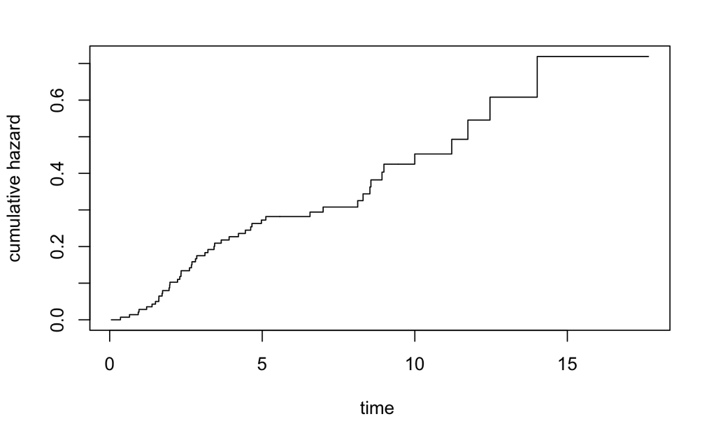

```r
# Aalen-Nelson hazard cumulato
na.haz = cumsum(fit$n.event / fit$n.risk)
plot(fit$time  , na.haz, type='s', xlab='time ', ylab='cumulative hazard')
```

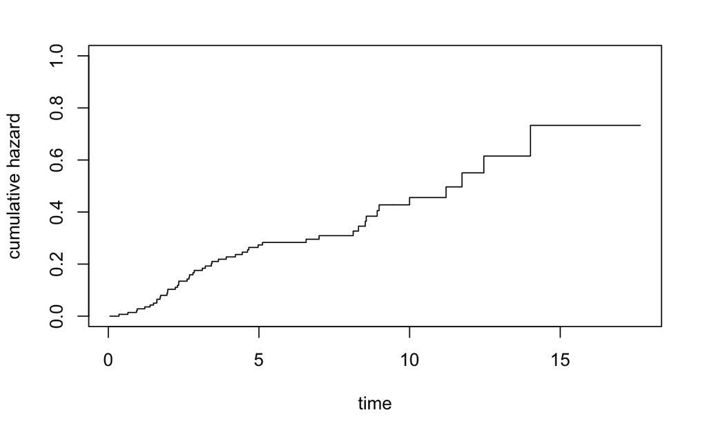

```r
# Relationship between survival and hazard
cumhaz =  -log(fit$surv)
plot(fit$time, cumhaz, type='s', ylim=c(0,1) , xlab='time', ylab='cumulative hazard')
```

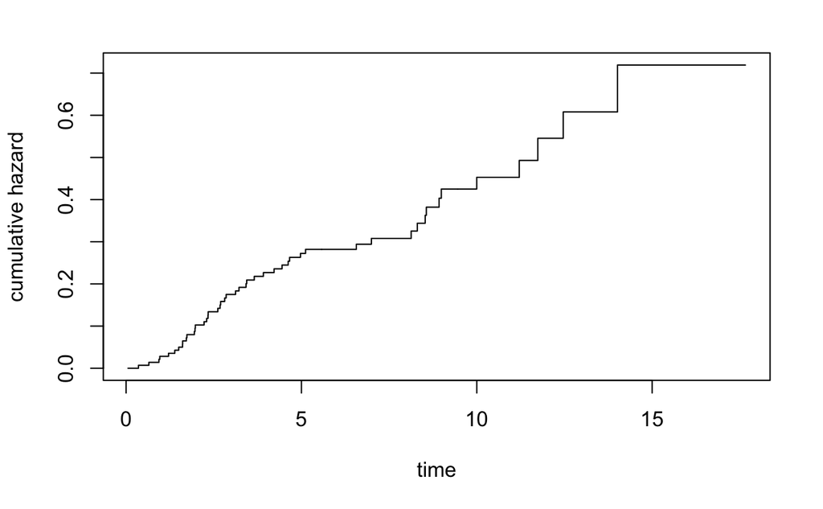

```r
# Basal hazard
b.haz = basehaz(coxph(Surv(dataset$time, dataset$event) ~ 1, method="exact") )
plot(b.haz$time  , b.haz$hazard, type='s', xlab='time', ylab='cumulative hazard')
```

```r
# Contrast the findings
plot(fit$time, na.haz, type='s', xlab='time (months)', ylab='cumulative hazard', ylim=c(0, 1))
points(fit$time, na.haz)
```

```r
lines(fit$time, cumhaz, type='s',col=2)
points(fit$time, cumhaz, pch=20,col=2)
```

```r
lines(b.haz$time, b.haz$hazard, type='s',col=3)
points(b.haz$time, b.haz$hazard, pch=5,col=3)
```

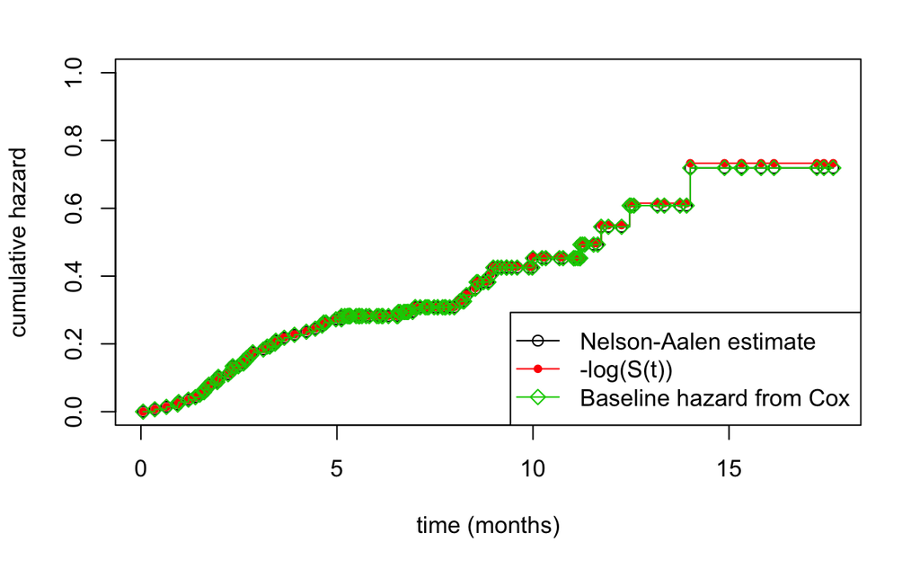

```r
legend("bottomright", legend=c("Nelson-Aalen estimate", "-log(S(t))", "Baseline hazard from Cox"),
       col=c(1, 2, 3), lty=1, pch=c(1, 20, 5))
```

#### Modello di Cox al basale

```r
model<-coxph(formula = Surv(time, event) ~ Diam + N + ER + factor(Grade) + Age, data = dataset)
summary(model)
```

```
Call:
coxph(formula = Surv(time, event) ~ Diam + N + ER + factor(Grade) +
    Age, data = dataset)

  n= 144, number of events= 48

                   coef exp(coef) se(coef)      z Pr(>|z|)
Diam            0.40347   1.49701  0.33061  1.220   0.2223
N               0.73700   2.08966  0.34171  2.157   0.0310 *
ER             -0.54480   0.57996  0.36723 -1.484   0.1379
factor(Grade)1 -0.04725   0.95385  0.34374 -0.137   0.8907
factor(Grade)2 -0.78353   0.45679  0.47074 -1.664   0.0960 .
Age            -0.04882   0.95235  0.02720 -1.795   0.0727 .
---
Signif. codes:  0 ‘***’ 0.001 ‘**’ 0.01 ‘*’ 0.05 ‘.’ 0.1 ‘ ’ 1

               exp(coef) exp(-coef) lower .95 upper .95
Diam              1.4970     0.6680    0.7831     2.862
N                 2.0897     0.4785    1.0696     4.083
ER                0.5800     1.7243    0.2824     1.191
factor(Grade)1    0.9539     1.0484    0.4863     1.871
factor(Grade)2    0.4568     2.1892    0.1816     1.149
Age               0.9523     1.0500    0.9029     1.005

Concordance= 0.712  (se = 0.04 )
Rsquare= 0.157   (max possible= 0.95 )
Likelihood ratio test= 24.56  on 6 df,   p=4e-04
Wald test            = 24.63  on 6 df,   p=4e-04
Score (logrank) test = 26.79  on 6 df,   p=2e-04
```

Cosa vediamo dal summary

- Il valore exp(coef) è quello più importante
- Vediamo che ad esempio Diam = 1 aumenta l’azzardo di un fattore pari a 1.497
- Grade = 2 riduce l’azzardo di un fattore pari a 0.45, questo va bene perchè grade = 2 è benigno
- Strano che l’eta faccia 0.95, mi aspetto che l’eta riduca la survival
- Non ho tante stelline quindi i test non sono molto significativi?
- Visto che Age ha quasi uno nell’upper .95 dovrebbe significare che non influisce quasi per nulla sulla predizione

Dobbiamo usare meno predittori?

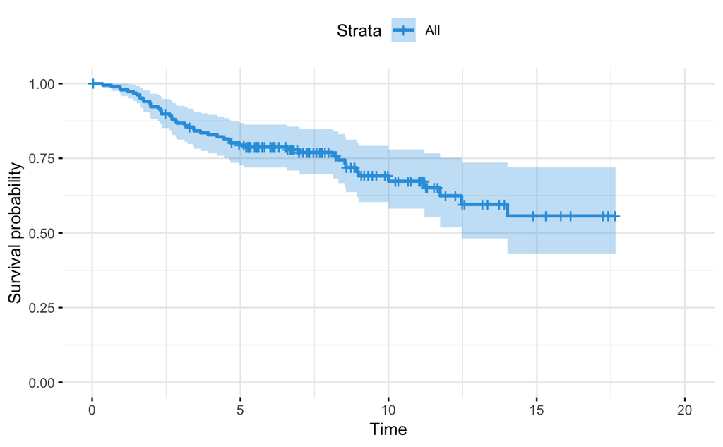

```r
ggsurvplot(survfit(model), data = dataset, palette = "#2E9FDF", ggtheme = theme_minimal())
```

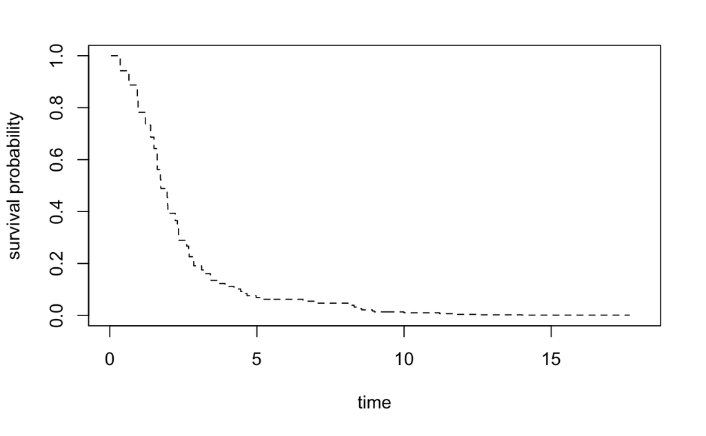

```r
# Modello basale
bas = basehaz(model, centered=FALSE)
bas.surv<- exp(-bas[, 1])
plot(bas$time, bas.surv, type='s', col=1, ylim=c(0, 1) , xlim=c(0, 18),lty=2, xlab='time', ylab='survival probability')
```

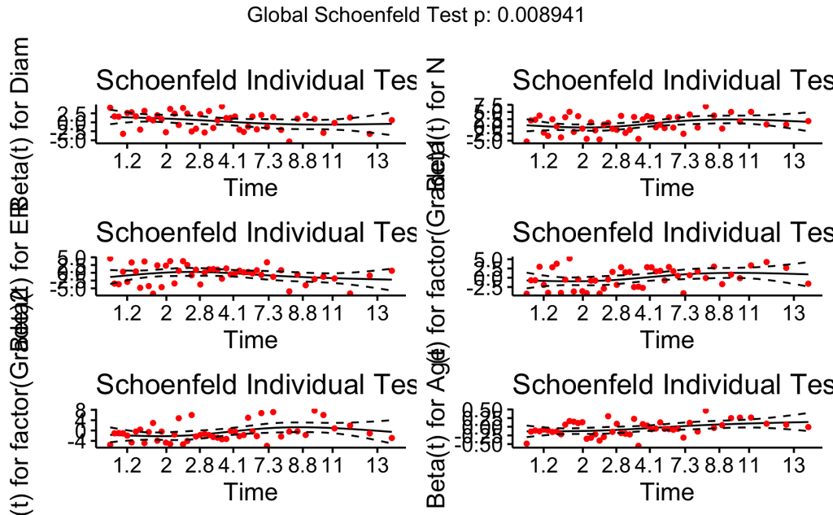

```r
# Residui di Schoenfeld
test.ph = cox.zph(model)
ggcoxzph(test.ph)
```

```r
# Verifica dei residui con il metodo di Lin
library(goftte)
prop(model)
```

```
In case of ties, use breslow method in coxph
```

```
Rejection p-values associated to Lin's approximation for proportional hazards assumption
---
Kolmogorov-Smirnov-test: p-value=0.292
Cramer-von-Mises-test: p-value=0.234
Anderson-Darling-test: p-value=0.28
Based on 1000 realizations. Cumulated residuals ordered by Diam-variable.
---
Kolmogorov-Smirnov-test: p-value=0.657
Cramer-von-Mises-test: p-value=0.634
Anderson-Darling-test: p-value=0.748
Based on 1000 realizations. Cumulated residuals ordered by N-variable.
---
Kolmogorov-Smirnov-test: p-value=0.313
Cramer-von-Mises-test: p-value=0.31
Anderson-Darling-test: p-value=0.38
Based on 1000 realizations. Cumulated residuals ordered by ER-variable.
---
Kolmogorov-Smirnov-test: p-value=0.127
Cramer-von-Mises-test: p-value=0.203
Anderson-Darling-test: p-value=0.232
Based on 1000 realizations. Cumulated residuals ordered by factor(Grade)1-variable.
---
Kolmogorov-Smirnov-test: p-value=0.143
Cramer-von-Mises-test: p-value=0.141
Anderson-Darling-test: p-value=0.131
Based on 1000 realizations. Cumulated residuals ordered by factor(Grade)2-variable.
---
Kolmogorov-Smirnov-test: p-value=0.176
Cramer-von-Mises-test: p-value=0.071
Anderson-Darling-test: p-value=0.039
Based on 1000 realizations. Cumulated residuals ordered by Age-variable.
---
```

```r
# Forma funzionale di age
# Knots è un parametro che va sistemato, forse non va bene
par(mfrow=c(1, 2),mar=c(4, 4, 2, 2))
mar.res<-resid(model, type='martingale')
plot(dataset$Age, mar.res,
     xlab="Time", ylab="Martingale Residuals",
     main="Check functional form of age")
lines(lowess(dataset$Age, mar.res),col='red')
```

```r
library(splines)
ms <- coxph(Surv(time, event > 0) ~ ns(Age, knots=c(20, 35, 45)), data = dataset)
pred <- predict(ms, type="terms", se=TRUE)
hfit <- pred$fit[,1]
hse <- pred$se[,1]
hmat <- cbind(hfit, hfit+1.96*hse,hfit-1.96*hse)
o <- order(dataset$Age)
matplot(dataset$Age[o], hmat[o, ], pch="*",col=c("red","orangered","orangered"), lwd=c(2,1,1),xlab = "Age", ylab="log hazard ratio",main="Check functional form of Age",type="l")
ms <- coxph(Surv(time, event > 0) ~ Age, data = dataset)
pred <- predict(ms, type="terms", se=TRUE)
hfit <- pred$fit[,1]
hse <- pred$se[,1]
hmat <- cbind(hfit, hfit+1.96*hse,hfit-1.96*hse)
o <- order(dataset$Age)
matplot(dataset$Age[o], hmat[o, ], pch="*",col=c("blue","cornflowerblue","cornflowerblue"), lwd=c(2,1,1),type="l",add=T)
```

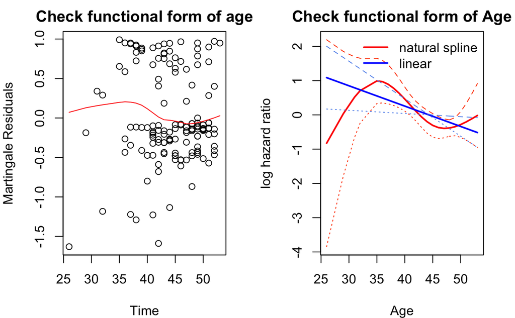

```r
legend("topright", c("natural spline", "linear"), col=c(2, 4), lwd=2, bty="n")
```

### **5. Valutazione della performance del modello**

es. calibrazione, discriminazione, Net Benefit. Per la predizione del rischio di evento ad un time-point fisso (es. 12 mesi).

```r
library(pROC)
library(pec)
source("stdca.R")
model = coxph(formula = Surv(time, event) ~ Diam + N + ER + factor(Grade) + Age, data = dataset)
summary(model)
```

```
Call:
coxph(formula = Surv(time, event) ~ Diam + N + ER + factor(Grade) +
    Age, data = dataset)

  n= 144, number of events= 48

                   coef exp(coef) se(coef)      z Pr(>|z|)
Diam            0.40347   1.49701  0.33061  1.220   0.2223
N               0.73700   2.08966  0.34171  2.157   0.0310 *
ER             -0.54480   0.57996  0.36723 -1.484   0.1379
factor(Grade)1 -0.04725   0.95385  0.34374 -0.137   0.8907
factor(Grade)2 -0.78353   0.45679  0.47074 -1.664   0.0960 .
Age            -0.04882   0.95235  0.02720 -1.795   0.0727 .
---
Signif. codes:  0 ‘***’ 0.001 ‘**’ 0.01 ‘*’ 0.05 ‘.’ 0.1 ‘ ’ 1

               exp(coef) exp(-coef) lower .95 upper .95
Diam              1.4970     0.6680    0.7831     2.862
N                 2.0897     0.4785    1.0696     4.083
ER                0.5800     1.7243    0.2824     1.191
factor(Grade)1    0.9539     1.0484    0.4863     1.871
factor(Grade)2    0.4568     2.1892    0.1816     1.149
Age               0.9523     1.0500    0.9029     1.005

Concordance= 0.712  (se = 0.04 )
Rsquare= 0.157   (max possible= 0.95 )
Likelihood ratio test= 24.56  on 6 df,   p=4e-04
Wald test            = 24.63  on 6 df,   p=4e-04
Score (logrank) test = 26.79  on 6 df,   p=2e-04
```

```r
# Predictiveness --------------------------------------------------------------------------------
fit = survfit(model, newdata = dataset)
dataset$riskdeath = 1 - as.numeric(summary(fit, times = 12)$surv)
dataset$event.12m = ifelse(dataset$time <= 12 & dataset$event == 1, 1, 0)
estmodel = survfit(Surv(riskdeath, event.12m) ~ 1, data=dataset)
# Predictiveness curve of model:
plot((1 - estmodel$surv) * 100, estmodel$time, main = '', type = 'l',
     ylim = c(0,1), lwd = 3, ylab = 'r', cex.lab = 1.7, cex.axis = 1.7,
     xlab = expression(paste('P(riskscore',''<='r)*100')), xaxt = "n", yaxt = "n", frame = F)
axis(2, at = c(0,0.2,0.4,0.6,0.8,1), labels = NA, pos = 0)
```

```r
axis(2, at = c(0,0.2,0.4,0.6,0.8,1), labels = c(0,0.2,0.4,0.6,0.8,1), cex.axis = 1.7, pos = 0)
axis(1, at = c(0,20,40,60,80,100), labels = c(0,20,40,60,80,100), cex.axis = 1.7, pos = 0)
```

```r
# Predictiveness curve of a useless model:
p = sum(dataset$event.12m) / dim(dataset)[1]
lines(c(0, 100), c(p, p), lty = 2, lwd = 3, col = 'gray')
text(40, 0.1, labels = bquote(rho ==  .(round(p,3)*100) ~ '%'), cex = 1.7)
```

```r
# Predictiveness curve of the ideal risk predictor:
lines(c(0, (1 - p) * 100), c(0, 0), lwd = 4)
lines(c((1 - p) * 100, (1 - p) * 100), c(0, 1), lwd = 4)
```

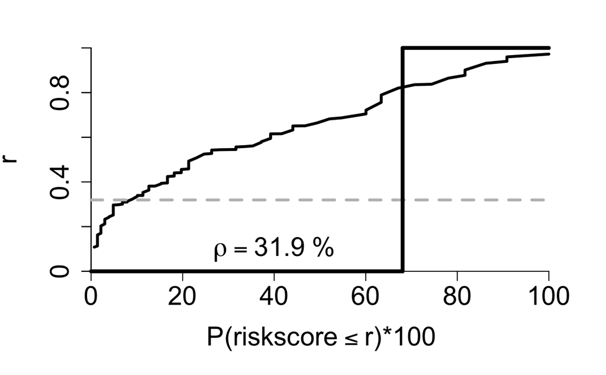

```r
lines(c((1 - p) * 100, 100), c(1, 1), lwd = 4)
```

```r
# Brier score
brier_score = mean((dataset$event.12m - dataset$riskdeath) ^ 2)
# Brier Score under strong calibration
brier_score_sc <- mean(dataset$riskdeath * (1 - dataset$riskdeath))
```

```r
# Discrimination --------------------------------------------
roc_model = roc(dataset$event.12m, dataset$riskdeath)
plot(1 - roc_model$specificities, roc_model$sensitivities,
     type = 'l', ylab = 'TPF', xlab = 'FPF', lwd = 3, xaxt = "n", yaxt = "n",
     xlim = c(0,1), cex.lab = 1.7, frame = F)
axis(1, at = c(0,0.25,0.5,0.75,1), labels = NA, pos = 0)
```

```r
axis(1, at = c(0,0.25,0.5,0.75,1), labels = c(0,0.25,0.5,0.75,1), cex.axis = 1.7, pos = 0)
axis(2, at = c(0,0.25,0.5,0.75,1), labels = c(0,0.25,0.5,0.75,1), cex.axis = 1.7, pos = 0)
```

```r
lines(x = c(0, 1), y = c(0, 1))
Youden = roc_model$sensitivities + roc_model$specificities - 1
optimal.cut.off = roc_model$thresholds[Youden == max(Youden)]
cbind(optimal.cut.off, Youden = max(Youden))
```

```
     optimal.cut.off    Youden
[1,]       0.3581396 0.3921917
```

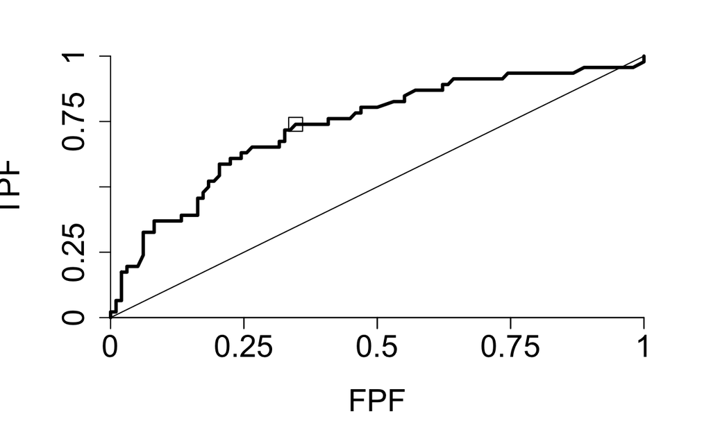

```r
points(1 - roc_model$specificities[roc_model$thresholds == optimal.cut.off],
           roc_model$sensitivities[roc_model$thresholds == optimal.cut.off],
           pch=0, cex=1.7)
```

```r
AUC = roc_model$auc
```

```r
# Brier score (adjusted for censoring) and the c-index. --------------------------------
# Non so se vada
model = coxph(formula = Surv(time, event) ~ Diam + N + ER + factor(Grade) + Age, data = dataset, x = T)
summary(model)
```

```
Call:
coxph(formula = Surv(time, event) ~ Diam + N + ER + factor(Grade) +
    Age, data = dataset, x = T)

  n= 144, number of events= 48

                   coef exp(coef) se(coef)      z Pr(>|z|)
Diam            0.40347   1.49701  0.33061  1.220   0.2223
N               0.73700   2.08966  0.34171  2.157   0.0310 *
ER             -0.54480   0.57996  0.36723 -1.484   0.1379
factor(Grade)1 -0.04725   0.95385  0.34374 -0.137   0.8907
factor(Grade)2 -0.78353   0.45679  0.47074 -1.664   0.0960 .
Age            -0.04882   0.95235  0.02720 -1.795   0.0727 .
---
Signif. codes:  0 ‘***’ 0.001 ‘**’ 0.01 ‘*’ 0.05 ‘.’ 0.1 ‘ ’ 1

               exp(coef) exp(-coef) lower .95 upper .95
Diam              1.4970     0.6680    0.7831     2.862
N                 2.0897     0.4785    1.0696     4.083
ER                0.5800     1.7243    0.2824     1.191
factor(Grade)1    0.9539     1.0484    0.4863     1.871
factor(Grade)2    0.4568     2.1892    0.1816     1.149
Age               0.9523     1.0500    0.9029     1.005

Concordance= 0.712  (se = 0.04 )
Rsquare= 0.157   (max possible= 0.95 )
Likelihood ratio test= 24.56  on 6 df,   p=4e-04
Wald test            = 24.63  on 6 df,   p=4e-04
Score (logrank) test = 26.79  on 6 df,   p=2e-04
```

```r
fit = survfit(model, newdata = dataset)
dataset$riskdeath = 1 - as.numeric(summary(fit, times = 12)$surv)
set.seed(10052019)
PredError = pec(
  model,
  maxtime = 17.65913758,
  formula = Surv(time, event == 1) ~ 1,
  data = dataset,
  cens.model = "marginal",
  splitMethod = "bootcv",
  B = 10,
  verbose = TRUE
)
```

```
Split sample loop (B=10)
1
2
3
4
5
6
7
8
9
10
```

```r
print(PredError, times = seq(0, 17.65913758, 1))
```

```
Prediction error curves

Prediction models:

Reference     coxph
Reference     coxph

Right-censored response of a survival model

No.Observations: 144

Pattern:
                Freq
 event          48
 right.censored 96

IPCW: marginal model

Method for estimating the prediction error:

Bootstrap cross-validation

Type: resampling
Bootstrap sample size:  144
No. bootstrap samples:  10
Sample size:  144

Cumulative prediction error, aka Integrated Brier score  (IBS)
 aka Cumulative rank probability score

Range of integration: 0 and time=0 time=1 time=2 time=3 time=4 time=5 time=6 time=7 time=8 time=9 time=10 time=11 time=12 time=13 time=14 time=15 time=16 time=17 :


Integrated Brier score (crps):

          IBS[0;time=0) IBS[0;time=1) IBS[0;time=2) IBS[0;time=3) IBS[0;time=4)
Reference             0         0.012         0.034         0.066         0.094
coxph                 0         0.012         0.035         0.065         0.091
          IBS[0;time=5) IBS[0;time=6) IBS[0;time=7) IBS[0;time=8) IBS[0;time=9)
Reference         0.114         0.130         0.141         0.150         0.159
coxph             0.110         0.125         0.136         0.145         0.154
          IBS[0;time=10) IBS[0;time=11) IBS[0;time=12) IBS[0;time=13) IBS[0;time=14)
Reference          0.167          0.174          0.181          0.188          0.195
coxph              0.163          0.173          0.182          0.193          0.204
          IBS[0;time=15) IBS[0;time=16) IBS[0;time=17)
Reference          0.203          0.209          0.215
coxph              0.216          0.230          0.240
```

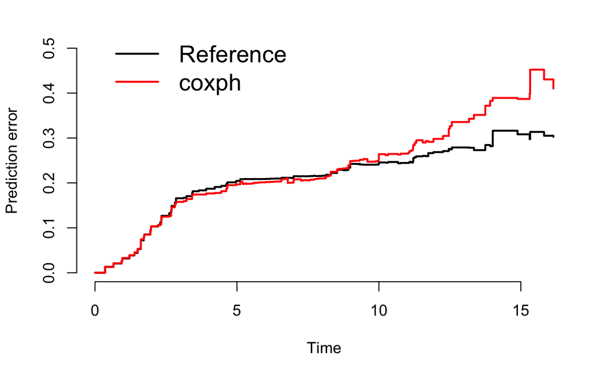

```r
par(mfrow = c(1,1))
plot(PredError)
```

```r
set.seed(1103)
BootCindex <- cindex(model,
                     formula = Surv(time, event == 1) ~ 1,
                     data = dataset,
                     eval.times = seq(1, 17.71, 1),
                     cens.model="marginal",
                     splitMethod="bootcv",
                     B=10,
                     verbose=TRUE)
```

```
1
2
3
4
5
6
7
8
9
10
```

```r
print(BootCindex)
```

```
The c-index for right censored event times

Prediction models:

coxph
coxph

Right-censored response of a survival model

No.Observations: 144

Pattern:
                Freq
 event          48
 right.censored 96

Censoring model for IPCW: marginal model (Kaplan-Meier for censoring distribution)

Method for estimating the prediction error:

Bootstrap cross-validation

Type: resampling
Bootstrap sample size:  144
No. bootstrap samples:  10
Sample size:  144

Estimated C-index in %

$AppCindex
      time=1 time=2 time=3 time=4 time=5 time=6 time=7 time=8 time=9 time=10 time=11
coxph   90.4   79.5     74   75.4   72.8   72.1   71.8   71.8   71.3    68.6    68.6
      time=12 time=13 time=14 time=15 time=16 time=17
coxph    68.9    65.8    65.8    67.9    67.9    67.9

$BootCvCindex
      time=1 time=2 time=3 time=4 time=5 time=6 time=7 time=8 time=9 time=10 time=11
coxph    NaN     76   71.3   71.5   69.7   69.5   69.1   69.1   69.2    67.9    67.9
      time=12 time=13 time=14 time=15 time=16 time=17
coxph    67.5    67.2    67.2    67.2    67.2    67.2


AppCindex    : Apparent (training data) performance
BootCvCindex : Bootstrap crossvalidated performance
```

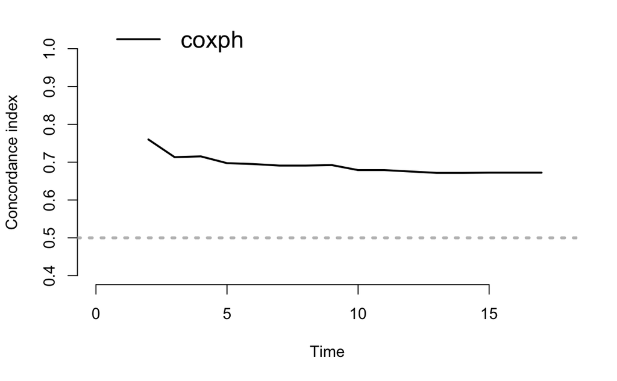

```r
plot(BootCindex)
```

```r
netbenefit <- stdca(data = dataset, outcome = "event", ttoutcome = "time", timepoint = 12,
                    predictors = c("riskdeath"))
```

```
[1] "riskdeath: No observations with risk greater than 73% that have followup through the timepoint selected, and therefore net benefit not calculable in this range."
```

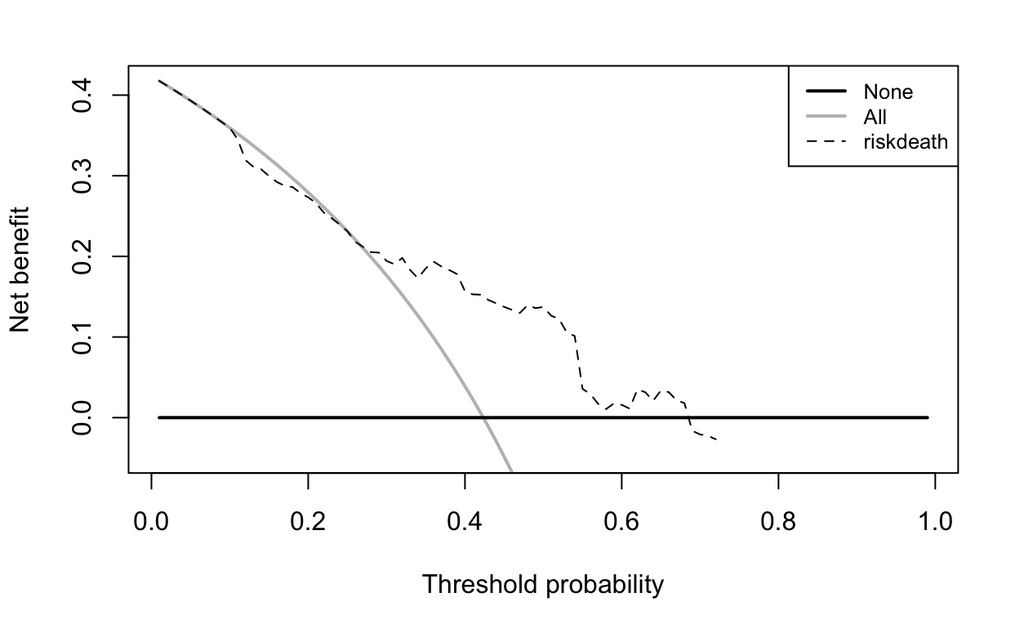

```r
par(mar = c(5, 4.5, 4, 1))
```

```r
# Net Benefit for model1:
plot(netbenefit$net.benefit$threshold, netbenefit$net.benefit$riskdeath, type = "l", lwd = 3, xlim = c(0, 1), ylim = c(0, 0.20), xlab = "r", ylab = "NB(r)", xaxt = "n", yaxt = "n", cex.lab = 1.7, cex.axis = 1.6, frame = F)
axis(1, at = c(0,0.2,0.4,0.6,0.8,1), labels = NA, pos = 0)
```

```r
axis(1, at = c(0,0.2,0.4,0.6,0.8,1), labels = c(0,0.2,0.4,0.6,0.8,1), cex.axis = 1.7, pos = 0)
axis(2, at = c(0,0.05,0.1,0.15,0.2), labels = c(0,0.05,0.1,0.15,0.2), cex.axis = 1.7, pos = 0)
```

```r
# We add an extra axis on the top of the graph with the costs:
axis(3, at = c(0,0.2,0.4,0.6,0.8,1), labels = c(0,0.25,0.67,1.5,4,'Inf'), cex.axis = 1.6)
mtext("C", side = 3, line = 2.5, cex = 1.7, las = 1)
```

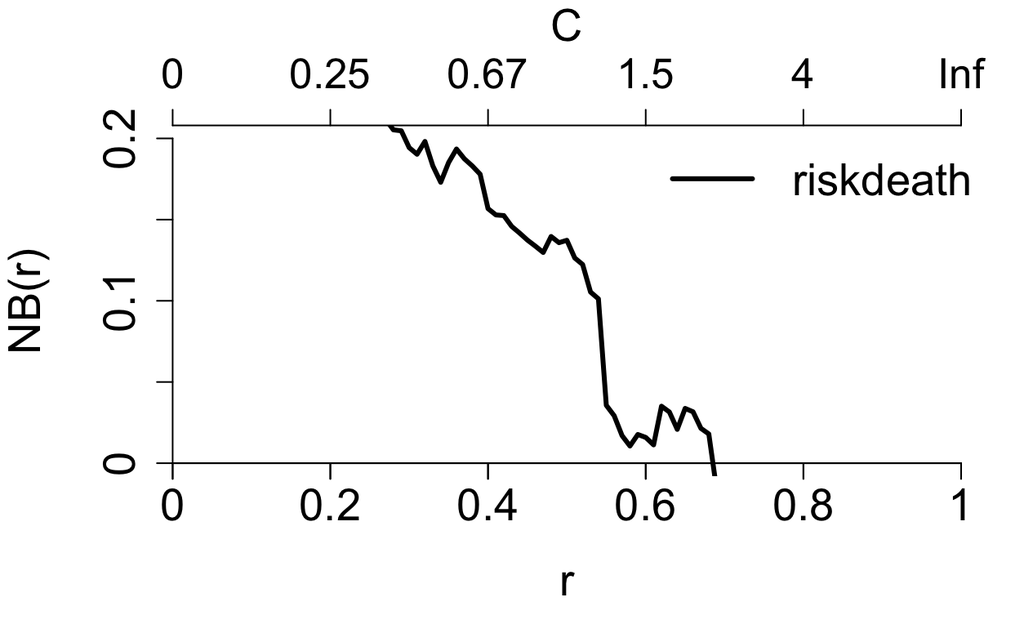

```r
legend('topright', c("riskdeath"), lwd = c(3, 3), lty = c(1, 3), col = c(1, 1), bty = 'n', cex = 1.7)
```

### **6. Regressione penalizzata su set di variabili di espressione genica**

```r
library(survival)
library(corrplot)
library(glmnet)
# carico il dataset
setwd(dirname(rstudioapi::getActiveDocumentContext()$path))
dataset = read.table("dataset.csv",  na.strings=".", sep = "\t",  header=T, row.names=NULL)
# Rimuovo l'id della riga
dataset = dataset[, -1]
# Prendo solo le covariate di espressione genica, il tempo e l'outcome
dataset = dataset[c(1, 2, 8:length(dataset))]
head(dataset)
```

|  | time | event | TSPYL5 | Contig63649_RC | DIAPH3 | NUSAP1 | AA555029_RC | ALDH4A1 | QSCN6L1 | FGF18 | DIAPH3.1 | Contig32125_RC | BBC3 | DIAPH3.2 | RP5.860F19.3 | C16orf61 | SCUBE2 | EXT1 | FLT1 | GNAZ | OXCT1 | MMP9 | RUNDC1 | Contig35251_RC | ECT2 | GMPS | KNTC2 | WISP1 | CDC42BPA | … |
| --- | --- | --- | --- | --- | --- | --- | --- | --- | --- | --- | --- | --- | --- | --- | --- | --- | --- | --- | --- | --- | --- | --- | --- | --- | --- | --- | --- | --- | --- | --- |
| 1 | 7.748118 | 0 | -0.18752814 | -0.15304662 | -0.29514052 | -0.56582890 | -0.21864109 | -0.18037880 | -0.18778528 | -0.3168283 | -0.30118455 | -0.11340617 | 0.01841731 | -0.12126035 | -0.15464786 | -0.27191718 | -0.5309360 | -0.22933165 | 0.02928248 | -0.16906364 | -0.17994325 | -0.06216645 | 0.08771493 | -0.03748896 | -0.14785939 | -0.25709099 | -0.12766957 | -0.103970962 | -0.22440171 | … |
| 2 | 4.662560 | 1 | 0.15099047 | -0.21005843 | 0.03355057 | 0.03654657 | -0.06474594 | -0.04812997 | -0.02583513 | -0.4251015 | 0.20449784 | 0.01609293 | 0.07505098 | 0.05913143 | -0.06155694 | -0.04152763 | 0.2755300 | -0.20714263 | -0.14841641 | -0.02920126 | -0.19713944 | -0.34564791 | -0.18203129 | -0.04763378 | 0.48057208 | -0.13851168 | 0.20359676 | 0.059727386 | 0.17774149 | … |
| 3 | 8.739220 | 0 | 0.11695046 | -0.25813878 | 0.07791766 | -0.08834376 | -0.31973700 | 0.12525019 | -0.08740829 | -0.2362195 | 0.23651714 | 0.16024944 | 0.11902553 | 0.07661457 | 0.23242917 | -0.18314464 | 0.2569269 | -0.27430646 | 0.04648250 | -0.13084890 | -0.21275367 | -0.58431851 | 0.13181509 | -0.13576519 | 0.12846822 | -0.40220331 | 0.27733344 | -0.104370258 | -0.30138575 | … |
| 4 | 7.567420 | 0 | 0.10493318 | -0.13687348 | -0.01984126 | -0.27212360 | -0.05067248 | 0.03215318 | -0.18070639 | -0.1419119 | -0.02985957 | 0.13519349 | 0.07215202 | -0.00671681 | -0.09624129 | -0.15029917 | 0.4460836 | 0.04636695 | -0.20511650 | 0.11025709 | -0.23951208 | -0.34800534 | 0.05287077 | -0.05992130 | -0.01444154 | 0.12604074 | -0.02530797 | -0.019752857 | -0.01414852 | … |
| 5 | 7.296372 | 0 | 0.30821656 | 0.03544526 | 0.15589646 | 0.17281797 | -0.13445797 | 0.36857538 | 0.17349207 | -0.4445576 | 0.10981625 | -0.03809348 | -0.29777674 | 0.06185603 | -0.20635196 | 0.19203352 | -1.0115741 | -0.04521220 | 0.08084737 | -0.34581318 | 0.02778352 | -0.33550292 | -0.04808210 | 0.59748058 | 0.14647630 | 0.05912505 | -0.09803689 | -0.115149133 | -0.10022007 | … |
| 6 | 6.718686 | 0 | -0.09643536 | -0.03772432 | -0.05882551 | 0.10173758 | -0.19559405 | 0.46424057 | 0.21204866 | -0.2425910 | 0.03225048 | -0.27078994 | 0.02057201 | 0.01687964 | 0.24147416 | 0.12535125 | -0.1460709 | -0.18753993 | 0.12485686 | -0.01081727 | 0.12973975 | -0.58003703 | 0.15926624 | -0.32724674 | -0.03543524 | -0.05018147 | -0.02103562 | -0.003368632 | 0.28115470 | … |

#### Kaplan-Meier

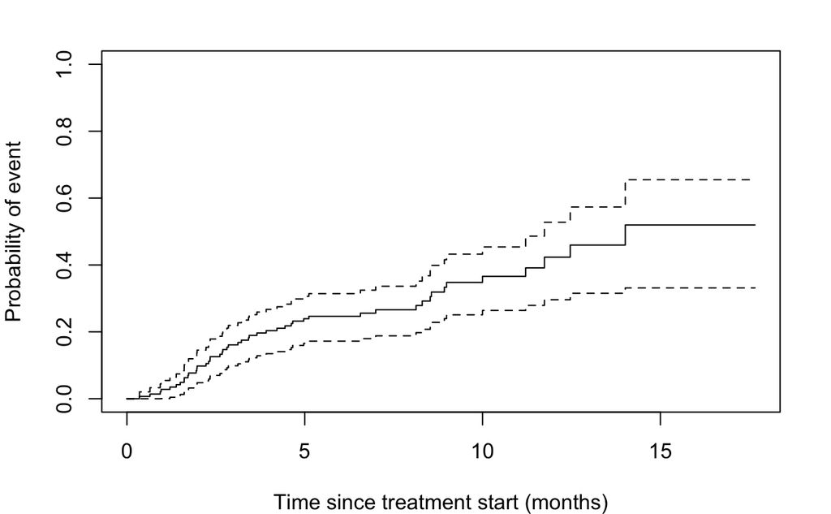

```r
fit<-survfit(Surv(time, event) ~ 1, data=dataset)
par(mar=c(4,4,2,2))
plot(fit, fun="F", xlab='Time since treatment start (months)', ylab='Probability of event',ylim=c(0,1))
```

#### Explore the correlation between the proteomic (forse non sono proteomic) features.

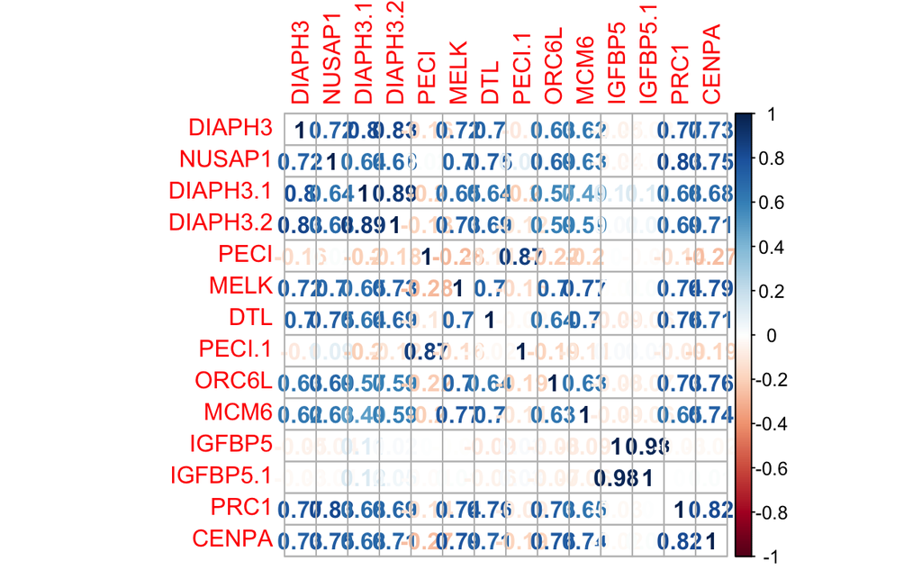

```r
corrs <- cor(dataset[,3:72])
a<-apply(corrs, 1, function(x) abs(x) > 0.75 & abs(x) < 1)
# variables with a correlation >0.75 with at least another variable
b<-rowSums(a)>0
vars<-names(b[b==T])
corrplot(cor(dataset[,vars]), method = "number")
```

#### Evaluate the association between each proteomic (forse) feature and the outcome using univariate Cox models.

```r
vars<-names(dataset[, 3:72])
output<-lapply(vars, function(var) {
  formula    <- as.formula(paste("Surv(time, event) ~ ", var))
  fit.uni    <- coxph(formula, data=dataset)
  beta       <- coef(fit.uni)
  se         <- sqrt(diag(fit.uni$var))
  CI         <- round(exp(confint(fit.uni)), 3)
  round(c(exp(beta), CI, p = 1 - pchisq((beta / se)^2, 1)), 3)
  })
results<-as.data.frame(matrix(unlist(output), ncol=4, byrow=T))
names(results) <- c("HR", "lower95%CI", "upper95%CI", "p")
results$features <- vars
results
```

| HR | lower95%CI | upper95%CI | p | features |
| --- | --- | --- | --- | --- |
| 1.112 | 0.465 | 2.660 | 0.811 | TSPYL5 |
| 3.671 | 1.109 | 12.149 | 0.033 | Contig63649_RC |
| 3.241 | 0.982 | 10.697 | 0.054 | DIAPH3 |
| 9.389 | 2.699 | 32.653 | 0.000 | NUSAP1 |
| 1.494 | 0.262 | 8.527 | 0.652 | AA555029_RC |
| 3.373 | 0.554 | 20.526 | 0.187 | ALDH4A1 |
| 9.574 | 3.005 | 30.501 | 0.000 | QSCN6L1 |
| 0.588 | 0.204 | 1.698 | 0.327 | FGF18 |
| 2.525 | 0.764 | 8.344 | 0.129 | DIAPH3.1 |
| 2.418 | 0.390 | 15.005 | 0.343 | Contig32125_RC |

[output cut: 60 more lines]

#### According to the results of the univariate analysis, find which features have a significant association with the outcome at 5% level. Check again which features would be selected after the application of a method to adjust for multiple comparisons by controlling the Family-Wise Error Rate (FWER, e.g. Holm procedure) or the False Discovery Rate (FDR, e.g. Benjamini-Hochberg procedure).

```r
results[results$p<0.05, ]
```

|  | HR | lower95%CI | upper95%CI | p | features |
| --- | --- | --- | --- | --- | --- |
| 2 | 3.671 | 1.109 | 12.149 | 0.033 | Contig63649_RC |
| 4 | 9.389 | 2.699 | 32.653 | 0.000 | NUSAP1 |
| 7 | 9.574 | 3.005 | 30.501 | 0.000 | QSCN6L1 |
| 15 | 0.505 | 0.290 | 0.879 | 0.016 | SCUBE2 |
| 24 | 3.801 | 1.037 | 13.933 | 0.044 | GMPS |
| 33 | 0.255 | 0.116 | 0.562 | 0.001 | ZNF533 |
| 34 | 0.134 | 0.026 | 0.680 | 0.015 | RTN4RL1 |
| 38 | 4.637 | 1.121 | 19.178 | 0.034 | Contig40831_RC |
| 40 | 6.524 | 1.781 | 23.901 | 0.005 | MELK |
| 41 | 11.381 | 1.535 | 84.397 | 0.017 | COL4A2 |

[output cut: 10 more lines]

```r
results$q.holm<-p.adjust(results$p, method="holm")
results$q.BH<-p.adjust(results$p, method="BH")
results[results$q.holm<0.05,]
```

|  | HR | lower95%CI | upper95%CI | p | features | q.holm | q.BH |
| --- | --- | --- | --- | --- | --- | --- | --- |
| 4 | 9.389 | 2.699 | 32.653 | 0 | NUSAP1 | 0 | 0 |
| 7 | 9.574 | 3.005 | 30.501 | 0 | QSCN6L1 | 0 | 0 |
| 64 | 16.283 | 4.736 | 55.986 | 0 | PRC1 | 0 | 0 |
| 66 | 5.379 | 2.088 | 13.855 | 0 | CENPA | 0 | 0 |

```r
results[results$q.BH<0.05,]
```

|  | HR | lower95%CI | upper95%CI | p | features | q.holm | q.BH |
| --- | --- | --- | --- | --- | --- | --- | --- |
| 4 | 9.389 | 2.699 | 32.653 | 0.000 | NUSAP1 | 0.000 | 0.00000000 |
| 7 | 9.574 | 3.005 | 30.501 | 0.000 | QSCN6L1 | 0.000 | 0.00000000 |
| 33 | 0.255 | 0.116 | 0.562 | 0.001 | ZNF533 | 0.066 | 0.01166667 |
| 40 | 6.524 | 1.781 | 23.901 | 0.005 | MELK | 0.310 | 0.03888889 |
| 49 | 6.429 | 2.084 | 19.834 | 0.001 | ORC6L | 0.066 | 0.01166667 |
| 57 | 2.667 | 1.323 | 5.376 | 0.006 | IGFBP5 | 0.366 | 0.04200000 |
| 60 | 3.149 | 1.483 | 6.685 | 0.003 | IGFBP5.1 | 0.189 | 0.02625000 |
| 64 | 16.283 | 4.736 | 55.986 | 0.000 | PRC1 | 0.000 | 0.00000000 |
| 66 | 5.379 | 2.088 | 13.855 | 0.000 | CENPA | 0.000 | 0.00000000 |
| 68 | 4.920 | 1.765 | 13.712 | 0.002 | NM_004702 | 0.128 | 0.02000000 |

#### Fit a multiple Cox model with Ridge penalty. Plot the estimated coefficients at each value of the shrinkage parameter lambda.

```r
X <- model.matrix(~., subset(dataset, select = -c(time, event)))
rigde.pen <- glmnet(x = X[, -1], y = Surv(dataset$time, dataset$event), family = "cox", alpha = 0, nlambda = 100)
lambdas <- rigde.pen$lambda
par(mar=c(4, 4, 5, 2))
plot(lambdas, lambdas, type ="n", xlab = bquote(beta), xlim = range(rigde.pen$beta),
     ylab = bquote(lambda), ylim = rev(range(lambdas)), yaxs = "i", log = "y")
abline(v = 0, lwd = 4)
```

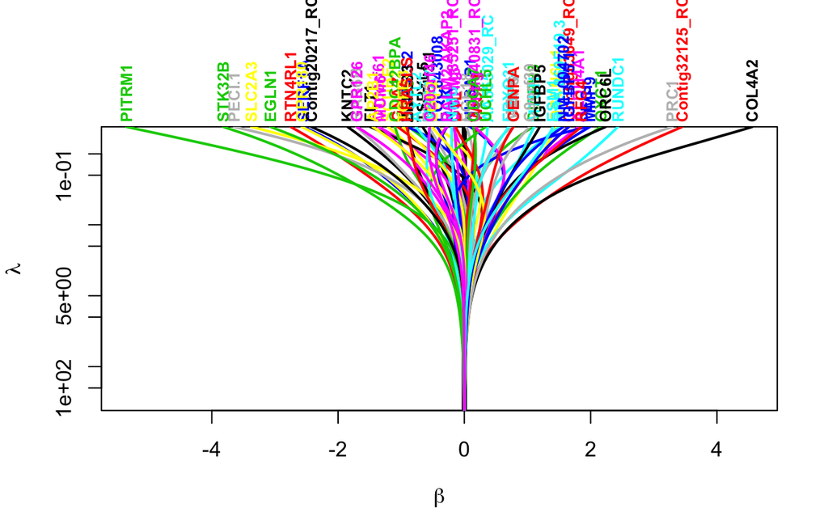

```r
for (i in 1:nrow(rigde.pen$beta)) lines(rigde.pen$beta[i, ], lambdas, col = i, lwd = 2)

mtext(rownames(rigde.pen$beta), 3, at = rigde.pen$beta[, 100], line = .2,
      col = 1:nrow(rigde.pen$beta), font = 2, las = 3, adj = 0, cex = .75)
```

#### Fit a multiple Cox model with Lasso penalty. Plot the estimated coefficients at each value of the shrinkage parameter lambda.

```r
X <- model.matrix(~., subset(dataset, select = -c(time, event)))
lasso.pen <- glmnet(x = X[, -1], y = Surv(dataset$time, dataset$event), family = "cox", alpha=1, nlambda = 100)
lambdas <- lasso.pen$lambda
par(mar = c(4, 4, 5, 2))
plot(lambdas, lambdas, type = "n", xlab = bquote(beta), xlim = range(lasso.pen$beta),
     ylab = bquote(lambda), ylim = rev(range(lambdas)), yaxs = "i", log = "y")
abline(v = 0, lwd = 4)
```

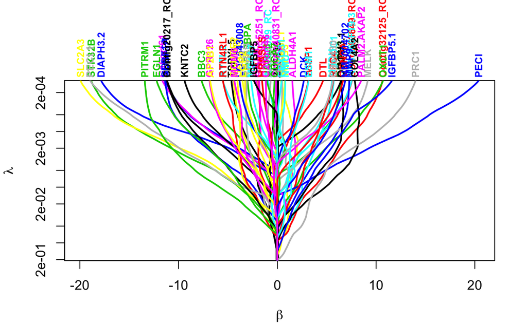

```r
for (i in 1:nrow(lasso.pen$beta)) lines(lasso.pen$beta[i, ], lambdas, col = i, lwd = 2)
mtext(rownames(lasso.pen$beta), 3, at = lasso.pen$beta[, length(lambdas)], line = .2,
      col = 1:nrow(lasso.pen$beta), font = 2, las = 3, adj = 0, cex = .75)
```

#### Fit a multiple Cox model with Lasso penalty using cross validation to find the optimal value of the shrinkage parameter. Find which features would be selected using the optimal lambda.

```r
X <- model.matrix(~., subset(dataset, select = -c(time, event)))
set.seed(16052019)
cv.lasso <- cv.glmnet(x = X[, -1], y = Surv(dataset$time, dataset$event), family = 'cox', nfold = 10, alpha=1)
```

[output not shown]

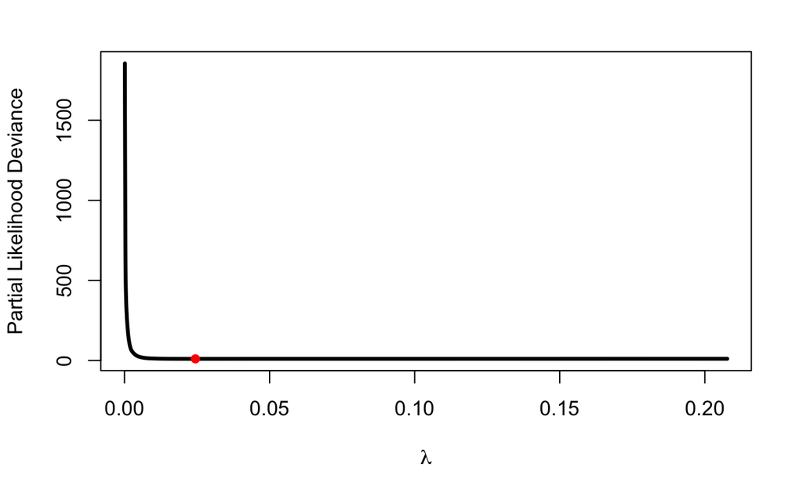

```r
plot(cv.lasso$lambda, cv.lasso$cvm, type = "l", lwd = 3, xlab = bquote(lambda), ylab = "Partial Likelihood Deviance")
points(cv.lasso$lambda[which.min(cv.lasso$cvm)], min(cv.lasso$cvm), pch = 16, col = 2)
```

```r
opt.lambda <- cv.lasso$lambda[which.min(cv.lasso$cvm)]
opt.lambda.coef <- as.numeric(coef(cv.lasso, s=opt.lambda))
# save coefficients (as HRs):
lasso.HR <- round(exp(opt.lambda.coef), 3)
#selected features:
rownames(coef(cv.lasso))[opt.lambda.coef!=0]
```

```
 [1] "TSPYL5"         "Contig63649_RC" "ALDH4A1"        "QSCN6L1"
 [5] "Contig32125_RC" "SCUBE2"         "OXCT1"          "MMP9"
 [9] "RUNDC1"         "KNTC2"          "SERF1A"         "GPR180"
[13] "RAB6B"          "ZNF533"         "RTN4RL1"        "MTDH"
[17] "Contig40831_RC" "COL4A2"         "STK32B"         "GPR126"
[21] "SLC2A3"         "PECI.1"         "ORC6L"          "RFC4"
[25] "MS4A7"          "AP2B1"          "HRASLS"         "PITRM1"
[29] "IGFBP5.1"       "PRC1"           "Contig20217_RC" "EGLN1"
[33] "ESM1"           "C20orf46"
```

#### Fit a multiple Cox model with Elastic Net penalty (set alpha=0.5) using cross validation to find the optimal value of the shrinkage parameter. Find which features would be selected using the optimal lambda.

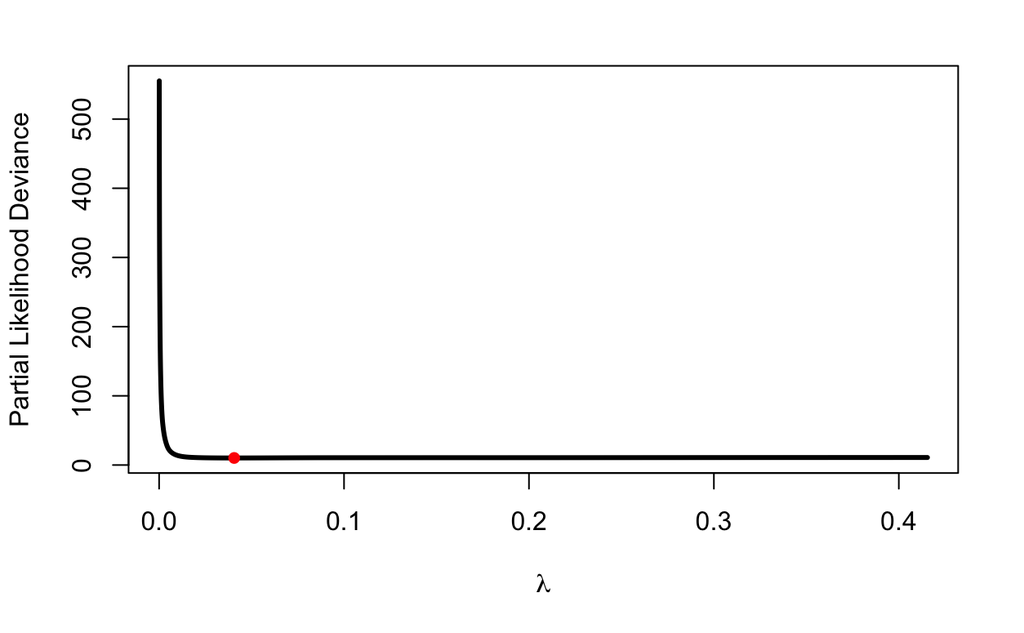

```r
X <- model.matrix(~., subset(dataset, select = -c(time, event)))
set.seed(16052019)
cv.el <- cv.glmnet(x = X[, -1], y = Surv(dataset$time, dataset$event), family = 'cox', nfold = 10, alpha=0.5)
plot(cv.el$lambda, cv.el$cvm, type = "l", lwd = 3, xlab = bquote(lambda), ylab = "Partial Likelihood Deviance")
points(cv.el$lambda[which.min(cv.el$cvm)], min(cv.el$cvm), pch = 16, col = 2)
```

```r
opt.lambda<-cv.el$lambda[which.min(cv.el$cvm)]
opt.lambda.coef<-as.numeric(coef(cv.el,s=opt.lambda))
#selected features:
rownames(coef(cv.el))[opt.lambda.coef!=0]
```

```
 [1] "TSPYL5"         "Contig63649_RC" "NUSAP1"         "ALDH4A1"
 [5] "QSCN6L1"        "Contig32125_RC" "SCUBE2"         "OXCT1"
 [9] "MMP9"           "RUNDC1"         "KNTC2"          "CDC42BPA"
[13] "SERF1A"         "GPR180"         "RAB6B"          "ZNF533"
[17] "RTN4RL1"        "MTDH"           "Contig40831_RC" "COL4A2"
[21] "STK32B"         "FBXO31"         "GPR126"         "SLC2A3"
[25] "PECI.1"         "ORC6L"          "RFC4"           "MS4A7"
[29] "AP2B1"          "IGFBP5"         "HRASLS"         "PITRM1"
[33] "IGFBP5.1"       "PRC1"           "Contig20217_RC" "EGLN1"
[37] "NM_004702"      "ESM1"           "C20orf46"
```

```r
# save coefficients (as HRs):
el.HR<-round(exp(opt.lambda.coef),3)
```

#### Fit a multiple Cox model with Adaptive Lasso penalty (use the inverse of the absolute value of the coefficients from a model with a Lasso penalty as features-specific penalties) using cross validation to find the optimal value of the shrinkage parameter. Find which features would be selected using the optimal lambda.

```r
X <- model.matrix(~., subset(dataset, select = -c(time, event)))
set.seed(16052019)
cv.lasso1 <- cv.glmnet(x = X[, -1], y = Surv(dataset$time, dataset$event), family = 'cox', nfold = 10, alpha=1)
```

[output not shown]

```r
best.coef <- as.numeric(coef(cv.lasso1, s=cv.lasso1$lambda[which.min(cv.lasso1$cvm)]))
round(best.coef,3)
```

```
 [1] -0.149  0.963  0.000  0.000  0.000  0.207  1.180  0.000  0.000  2.056  0.000
[12]  0.000  0.000  0.000 -0.543  0.000  0.000  0.000  0.495  1.149  1.898  0.000
[23]  0.000  0.000 -1.025  0.000  0.000 -0.987  0.000  0.000 -1.346 -1.065 -0.817
[34] -1.636  0.000  0.000  0.603  0.806  0.000  0.000  2.169  0.000 -1.611  0.000
[45]  0.000 -0.521 -0.975 -0.488  1.412  0.914  0.000  0.000 -0.512  0.000 -0.117
[56]  0.000  0.000 -0.109 -2.959  1.575  0.000  0.000  0.000  3.092 -1.471  0.000
[67] -2.003  0.000  0.741 -0.219
```

```r
set.seed(16052019)
cv.adlasso <- cv.glmnet(x = X[, -1], y = Surv(dataset$time, dataset$event), family = 'cox',
                      penalty.factor = 1 / abs(best.coef), nfold = 10, alpha=1)
opt.lambda <- cv.adlasso$lambda[which.min(cv.adlasso$cvm)]
opt.lambda.coef<-as.numeric(coef(cv.adlasso,s=opt.lambda))
# save coefficients (as HRs):
adlasso.HR<-round(exp(opt.lambda.coef),3)
# selected features:
rownames(coef(cv.adlasso))[opt.lambda.coef!=0]
```

```
 [1] "Contig63649_RC" "QSCN6L1"        "Contig32125_RC" "SCUBE2"
 [5] "OXCT1"          "MMP9"           "RUNDC1"         "KNTC2"
 [9] "SERF1A"         "GPR180"         "RAB6B"          "ZNF533"
[13] "RTN4RL1"        "MTDH"           "Contig40831_RC" "COL4A2"
[17] "STK32B"         "GPR126"         "SLC2A3"         "PECI.1"
[21] "ORC6L"          "RFC4"           "MS4A7"          "PITRM1"
[25] "IGFBP5.1"       "PRC1"           "Contig20217_RC" "EGLN1"
[29] "ESM1"
```

#### Compare the selected features and the estimated association parameters (HRs) according to all penalized models and the univariate analysis

```r
cbind(features=results$features, univariate.HR=results$HR, lasso.HR, el.HR,adlasso.HR)
```

```
      features         univariate.HR lasso.HR el.HR    adlasso.HR
 [1,] "TSPYL5"         "1.112"       "0.861"  "0.863"  "1"
 [2,] "Contig63649_RC" "3.671"       "2.62"   "2.499"  "4.336"
 [3,] "DIAPH3"         "3.241"       "1"      "1"      "1"
 [4,] "NUSAP1"         "9.389"       "1"      "1.398"  "1"
 [5,] "AA555029_RC"    "1.494"       "1"      "1"      "1"
 [6,] "ALDH4A1"        "3.373"       "1.23"   "1.727"  "1"
 [7,] "QSCN6L1"        "9.574"       "3.255"  "3.428"  "3.747"
 [8,] "FGF18"          "0.588"       "1"      "1"      "1"
 [9,] "DIAPH3.1"       "2.525"       "1"      "1"      "1"
[10,] "Contig32125_RC" "2.418"       "7.818"  "7.387"  "18.857"
[11,] "BBC3"           "0.589"       "1"      "1"      "1"
[12,] "DIAPH3.2"       "5.608"       "1"      "1"      "1"
[13,] "RP5.860F19.3"   "0.754"       "1"      "1"      "1"
[14,] "C16orf61"       "3.382"       "1"      "1"      "1"
```

[output cut: 56 more lines]